# Estimator Trials

2025-03-25

## Linear model with correlated predictors and heterokedasticity (n=100, rho=0.6)

### Case for p/n very high (p/n=0.9)

```r
set.seed(3)
n <- 100
k <- 1.1 # number of observations per coefficient
p <- floor(n/k) #number of variables
rho <- 0.6
beta <- rep(0.5, p)
Sigma <- matrix(rho, p, p)  # Correlation matrix
diag(Sigma) <- 1  # Set diagonal to 1 for variances
mu <- rep(0,p)
X <- mvrnorm(n, mu, Sigma) # simplified setting: all predictors are orthogonal

# Introduce heteroskedasticity: variance depends on X
gamma <- runif(p, -0.3, 0.3)  # Random coefficients for variance scaling
error_sd <- exp(X %*% gamma)  # Heteroskedastic error standard deviation
errors <- rnorm(n, mean = 0, sd = error_sd)  # Heteroskedastic errors
Y <- X%*%beta + errors
```

I had to change the seed to 3 because 1 gave a small vector when p is 5 (last case). Gamma is now:

```r
gamma[0:10]
```

```
##  [1] -0.08216832 -0.23656899 -0.14659021 -0.27518640 -0.02891345  0.15445911
##  [7] -0.25905840 -0.17818772 -0.08996040  0.02103941
```

We fit first an OLS model with intercept which yields quite bad results:

```r
m1 <- lm(Y ~ X)
coef(m1)[1:10]
```

```
## (Intercept)          X1          X2          X3          X4          X5
##  3.31531017  6.67350398  0.02473921  1.30751904 -2.34998873  3.01354647
##          X6          X7          X8          X9
## -0.50480326  2.22144667 -0.33280379  1.85425062
```

We compute the estimate for X1 when partialling out (FWL theorem).

```r
mY <- lm(Y ~ X[,-1])
mX1 <- lm(X[,1] ~ X[,-1])
Y.tilde <- mY$residuals
X1.tilde <- mX1$residuals
m2 <- lm(Y.tilde ~ X1.tilde -1 ) # no intercept
```

OLS:

```r
coef(summary(m1))[2,]
```

```
##   Estimate Std. Error    t value   Pr(>|t|)
## 6.67350398 3.17850564 2.09957280 0.06516344
```

Partialllng out:

```r
coef(summary(m2))
```

```
##          Estimate Std. Error  t value     Pr(>|t|)
## X1.tilde 6.673504  0.9583555 6.963495 3.684291e-10
```

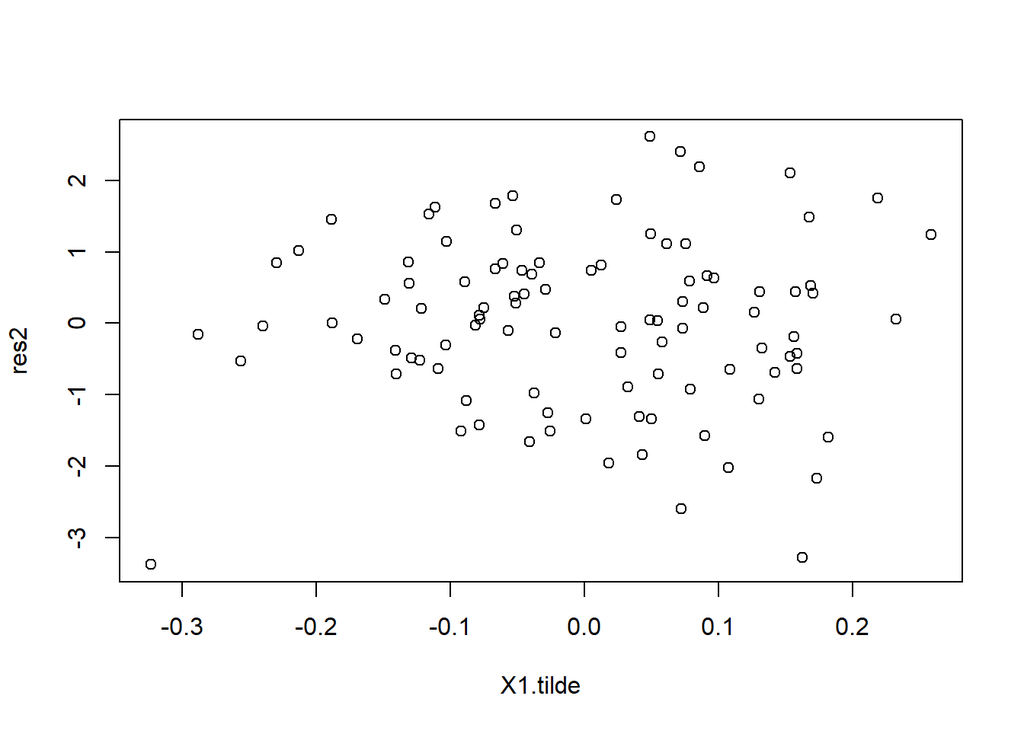

```r
# Plot to check heterokedasticity in the second step regression
res2 <- resid(m2)
plot(X1.tilde,res2)
```

```r
lm(res2**2  ~ X1.tilde) %>% summary
```

```
##
## Call:
## lm(formula = res2^2 ~ X1.tilde)
##
## Residuals:
##     Min      1Q  Median      3Q     Max
## -1.6672 -1.1933 -0.8013  0.4710 10.4217
##
## Coefficients:
##             Estimate Std. Error t value Pr(>|t|)
## (Intercept)   1.3762     0.2056   6.693 1.37e-09 ***
## X1.tilde      1.2687     1.6713   0.759     0.45
## ---
## Signif. codes:  0 '***' 0.001 '**' 0.01 '*' 0.05 '.' 0.1 ' ' 1
##
## Residual standard error: 2.056 on 98 degrees of freedom
## Multiple R-squared:  0.005846,   Adjusted R-squared:  -0.004299
## F-statistic: 0.5762 on 1 and 98 DF,  p-value: 0.4496
```

The second regresison model seems to have homokedastic errors, even if the original model is heterokedastic.

```
##        beta.LR    SE.LR  SE.LRHW  SE.LRJN   beta.PO    SE.PO  SE.POHW  SE.POJN
## Mean 0.5879053 3.826456 1.122496 14.30237 0.5879053 1.153720 1.122496 22.62091
## SD   4.9328888 3.890793 1.120782 14.72771 4.9328888 1.173118 1.120782 24.28929
```

**NOTE** I made the mistake of computing a new gamma for every simulation, however when we fit a model and we try to come up with a CI the reasoning is: if I drew data many times from this Data generating model and computed my beta estimate and my CI every time, the real value would fall 95% of times inside the CI. Therefore, it is important that when I compare the s.e. estimates with the s.d. of the beta I do it leaving the model untouched for every simulation.

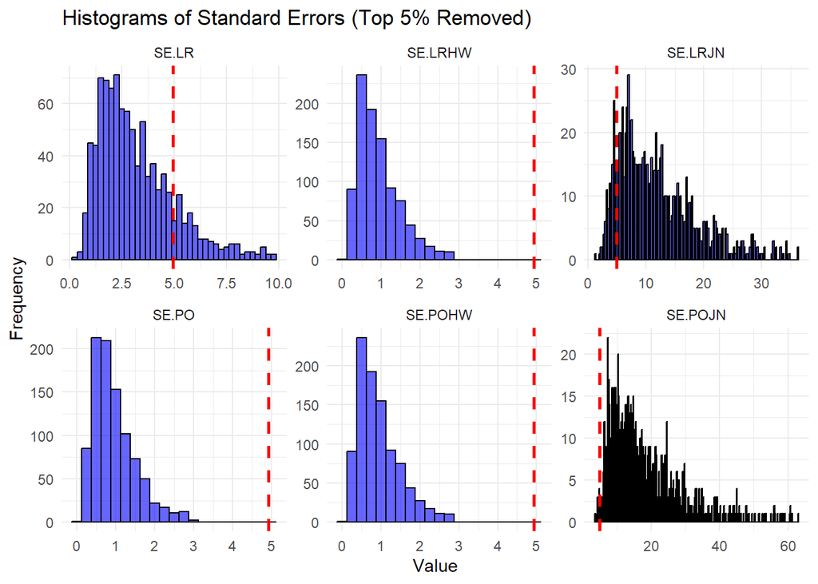

```r
# Convert results_df to long format for ggplot
results_long <- reshape2::melt(results_df[, c("SE.LR", "SE.LRHW", "SE.LRJN", "SE.PO", "SE.POHW", "SE.POJN")])
# Compute the 95th percentile for each variable
quantiles <- results_long %>%
  group_by(variable) %>%
  summarise(upper = quantile(value, 0.95, na.rm = TRUE))

# Merge the quantiles with the original data
results_filtered <- inner_join(results_long, quantiles, by = "variable")

# Remove only the highest 5% of values
results_filtered <- results_filtered %>%
  filter(value <= upper)

# Compute the standard deviation of beta.LR
beta_LR_sd <- sd(results_df$beta.LR, na.rm = TRUE)

# Plot histograms with individual y-axes
ggplot(results_filtered, aes(x = value)) +
  geom_histogram(binwidth = 0.25, fill = "blue", alpha = 0.6, color = "black") +
  facet_wrap(~variable, scales = "free") +  # Free scales for both x and y axes
  geom_vline(xintercept = beta_LR_sd, color = "red", linetype = "dashed", size = 1) + # Red vertical line
  theme_minimal() +
  labs(title = "Histograms of Standard Errors (Top 5% Removed)", x = "Value", y = "Frequency")
```

### Case for p/n high (p/n=0.5)

We fit first an OLS model with intercept which yields somewhat better results:

```
## (Intercept)          X1          X2          X3          X4          X5
##   1.8693537  -0.5388623   2.0842712   1.2887791  -1.8271236   0.9297124
##          X6          X7          X8          X9
##   1.1197404   0.7822742   1.1858358   0.3558222
```

We compute the estimate for X1 when partialling out (FWL theorem).

OLS:

```
##   Estimate Std. Error    t value   Pr(>|t|)
## -0.5388623  1.1989413 -0.4494485  0.6550900
```

Partialllng out:

```
##            Estimate Std. Error    t value  Pr(>|t|)
## X1.tilde -0.5388623  0.8434869 -0.6388509 0.5243953
```

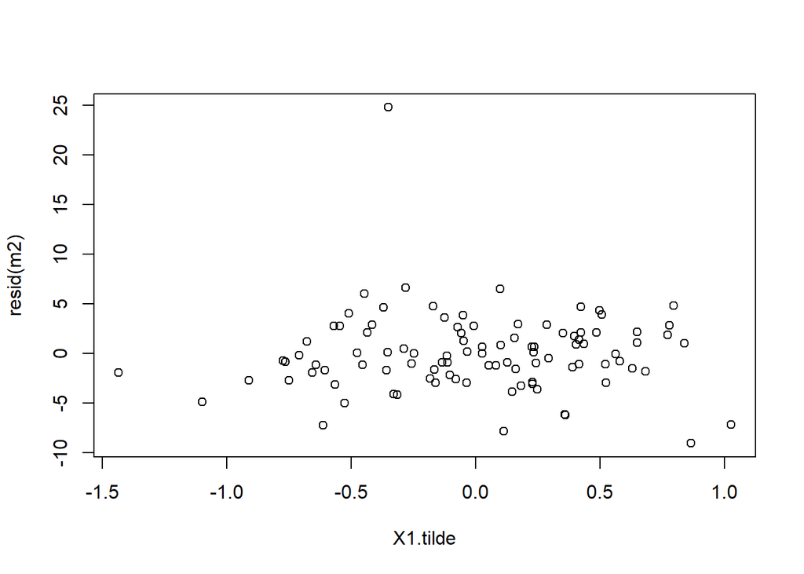

Let’s run the simulations:

```
##        beta.LR     SE.LR   SE.LRHW  SE.LRJN   beta.PO     SE.PO   SE.POHW
## Mean 0.4823877 1.2318823 0.8248576 1.772387 0.4823877 0.8666618 0.8248576
## SD   1.4358863 0.9788432 0.6338864 1.375184 1.4358863 0.6886421 0.6338864
##       SE.POJN
## Mean 2.341955
## SD   1.863187
```

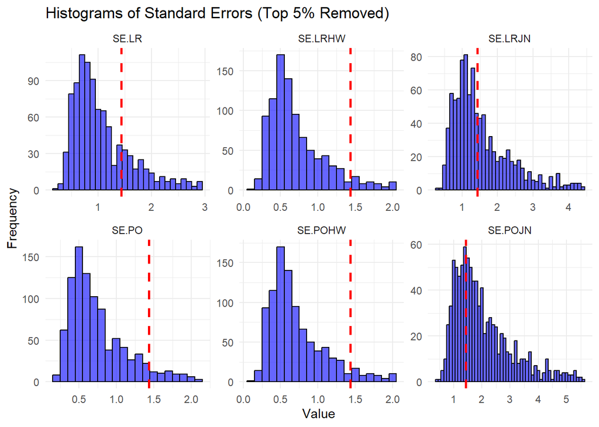

### Case for p/n small (p/n=0.05)

The gamma vector equals:

```r
gamma
```

```
## [1] -0.72572434 -0.51532398 -0.59518725 -0.05140633  0.04979501
```

We fit first an OLS model with intercept which yields much better results:

```
## (Intercept)          X1          X2          X3          X4          X5
##  -0.1089681   0.6076016   0.3400326   0.8473102   0.3215405   0.5615707
```

We compute the estimate for X1 when partialling out (FWL theorem).

OLS:

```
##   Estimate Std. Error    t value   Pr(>|t|)
##  0.6076016  0.4099875  1.4820006  0.1416848
```

Partialllng out:

```
##           Estimate Std. Error  t value  Pr(>|t|)
## X1.tilde 0.6076016  0.3995001 1.520905 0.1314713
```

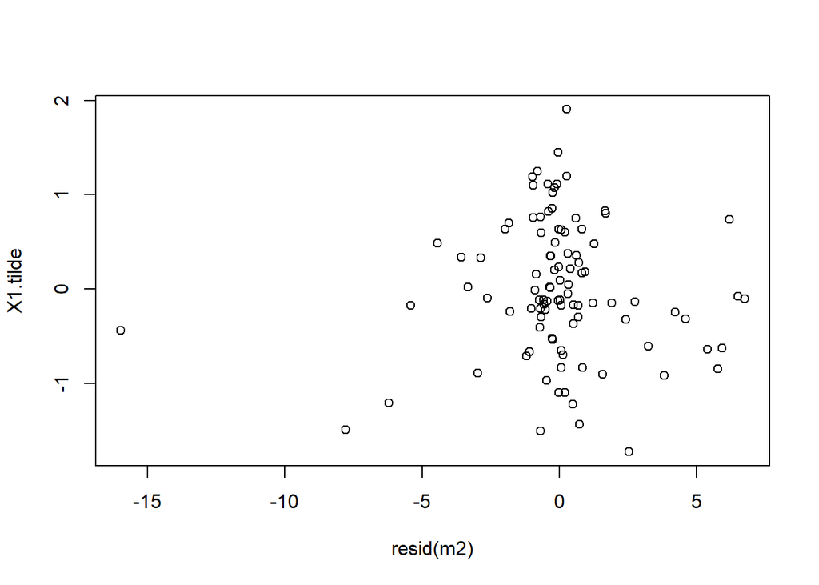

```
##        beta.LR     SE.LR   SE.LRHW   SE.LRJN   beta.PO     SE.PO   SE.POHW
## Mean 0.4893021 0.2946400 0.4119370 0.4612919 0.4893021 0.2871032 0.4119370
## SD   0.5483982 0.1118087 0.2722342 0.3322585 0.5483982 0.1089487 0.2722342
##        SE.POJN
## Mean 0.4174643
## SD   0.2730703
```

For a smaller p/n and high heterokedasticity they all behave badly, with the usual OLS being the worst and JN begint the best.

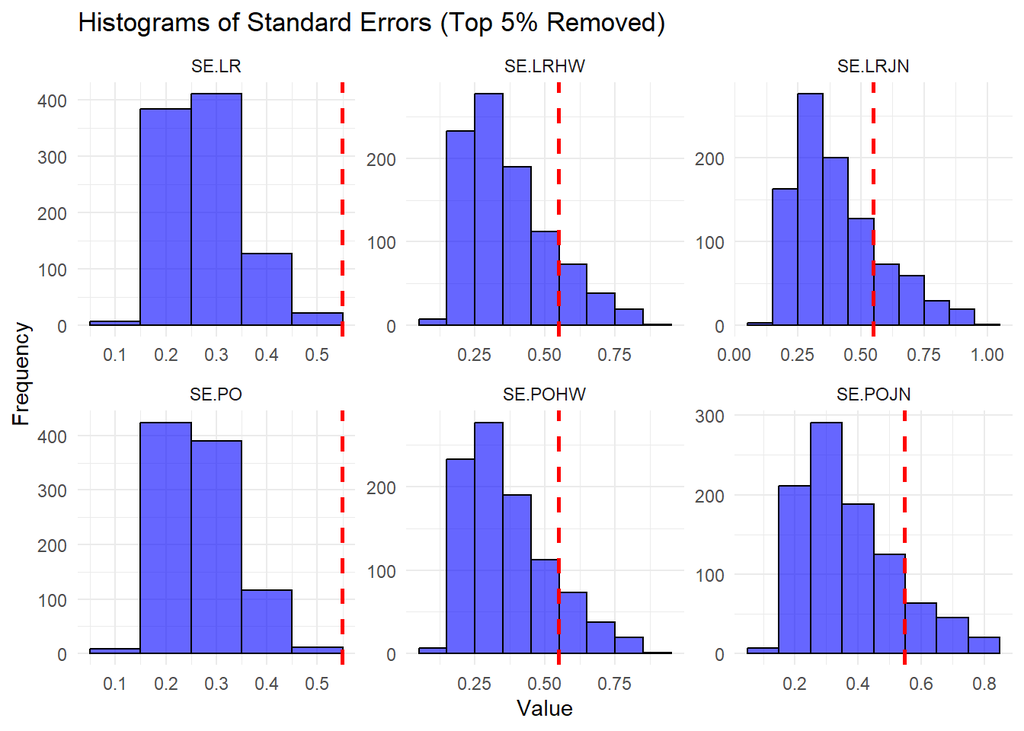